# Paquetes R

3/30/2019

## Presentacion

- @pdelboca
- Ingeniero en Sistemas de Información y entusiasta de los datos
- Desarrollador Python en Datopian
- Presidente de Open Data Córdoba

## Agenda

- ¿Qué es un paquete?
- Estructura de un Paquete
- Componentes más importantes
- Armando un Paquete para acceder a APIs
- Mejores Prácticas
- Beneficios

## ¿Qué es un paquete?

Los paquetes son las unidades fundamentales de código R reproducible. Incluyen **funciones** de R *reutilizables*, la **documentación** que describe cómo usarlas y **datos** de muestra.

## ¿Qué es un paquete?

En R, la unidad fundamental del código compartible es el paquete. Un paquete agrupa código, datos, documentación, pruebas, y es fácil de compartir con otros.

## ¿Qué es un paquete?

Mostrar código, datos, documentacion, tests.

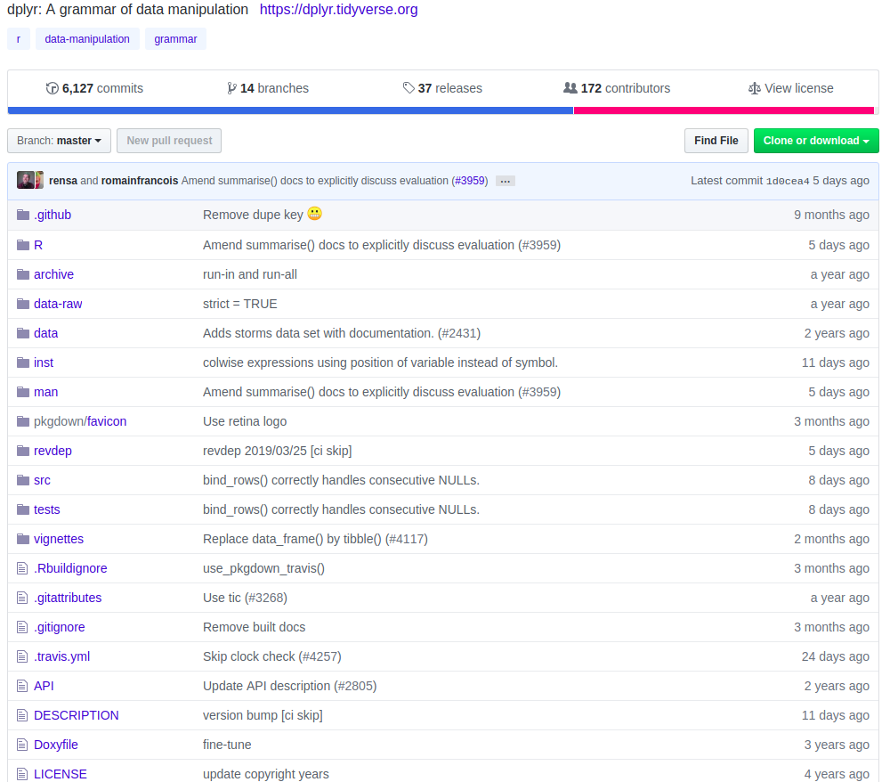

## ¿Qué es un paquete?

A source package is just a directory with components like R/, DESCRIPTION, and so on.

## Beneficios

> “Seriously, it doesn’t have to be about sharing your code (although that is an added benefit!). It is about saving yourself time. (Hilary Parker)”

Organizar el código en un paquete facilita su vida porque los paquetes vienen con convenciones. Por ejemplo, pones el código R en **R/**, pruebas en **tests/** y datos en **data/**.

## Beneficios

[figure not shown]

## Usando Paquetes

When you load a script with source(), every line of code is executed and the results are immediately made available. Things are different in a package, because it is loaded in two steps. When the package is built (e.g. by CRAN) all the code in R/ is executed and the results are saved. When you load a package, with library() or require(), the cached results are made available to you. If you loaded scripts in the same way as packages, your code would look like this:

```r
# Load a script into a new environment and save it
env <- new.env(parent = emptyenv())
source("my-script.R", local = env)
save(envir = env, "my-script.Rdata")

# Later, in another R session
load("my-script.Rdata")
```

## R/

El primer principio para crear un paquete es que todo el código R va en **R/**.

El código R en los paquetes tiene el objetivo de crear objetos (mayoritariamente funciones).